# Introducción (rápida) a `R`

José Rodríguez de la Fuente - Albano Vergara Parra

Facultad de Ciencias Sociales - UBA  
Doctorado en Ciencias Sociales  
Seminario: *Introducción al uso y aplicación de paquetes estadísticos para el tratamiento de fuentes de información en investigación social cuantitativa*

## Bibliografía introductoria recomendada

- [Wickham, Hadley & Grolemund, Garrett (2016). R for data science: Import, tidy, transform, visualize, and model data. O’Reilly Media, Inc. (Capítulo 1)](https://es.r4ds.hadley.nz/)
- [Vazquez Brust, Antonio (2021). Ciencia de Datos para Gente Sociable. Una introducción a la exploración, análisis y visualización de datos](https://bitsandbricks.github.io/ciencia_de_datos_gente_sociable/)
- [Sacco, Nicolás; José Rodríguez de la Fuente y Sofía Jaime (2022). Libro de Cocina para el Análisis de las Clases Sociales en Argentina.](https://nsacco.github.io/clases-arg/index.html)

# 1. ¿Por qué usar `R`?

## Ventajas

- Código abierto: amplia cantidad de paquetes
- Es gratuito
- Puede abrir varias bases de datos al mismo tiempo: usa la memoria virtual
- Gran comunidad de usuarios (foros) - **sentido de pertenencia**
- Uso extendido en la ciencia (sociales) y ámbito profesional
- Producción de gráficos de alta calidad
- Capacidad de elaborar tableros, aplicaciones, documentos, páginas web, presentaciones, etc.

## Desventajas (1)

- Las órdenes deben darse por sintaxis (no hay mucho *point and click*)
- Hacer cosas *sencillas* y *rápidas* puede llevar más tiempo que en otros programas
- La curva de aprendizaje es lenta

## Desventajas (2)

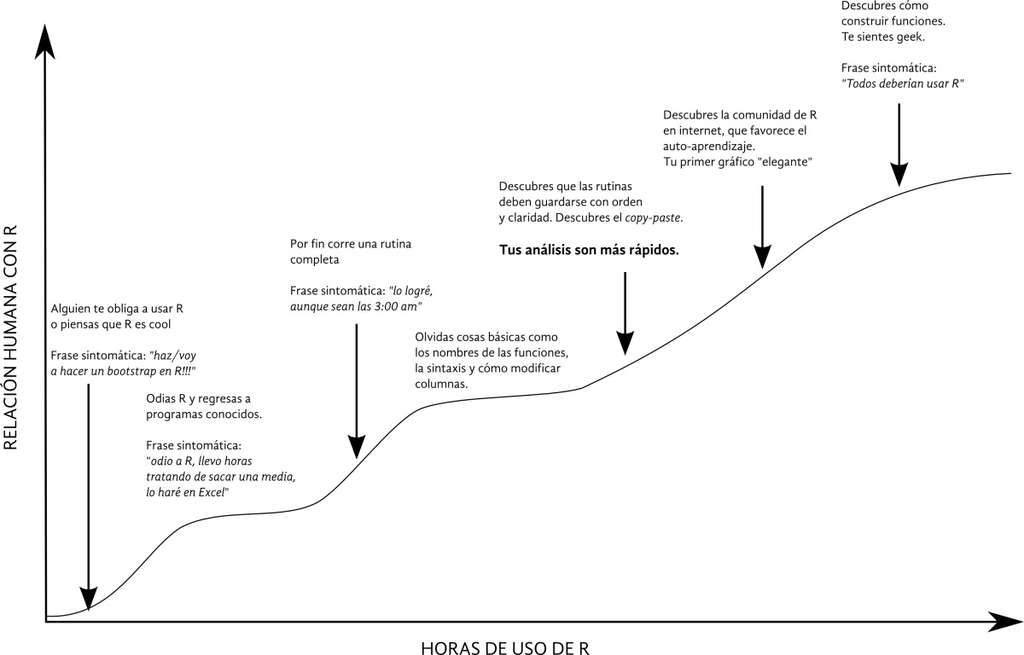

## Desventajas (3)

[figure not shown]

## Comparaciones con otros programas

| **Software** | **Interfaz** | **Curva de aprendizaje** | **Manipulación de data** | **Análisis estadístico** | **Gráficos** | **Especialidades** |
| --- | --- | --- | --- | --- | --- | --- |
| *SPSS* | **Menus & Sintaxis** | **Gradual** | **Moderada** | Alcance moderado Baja versatilidad | **Buenos** | **Tablas personalizadas, ANOVA & Análisis multivariado** |
| *Stata* | **Menus & Sintaxis** | **Moderado** | **Fuerte** | Amplio alcance Media versatilidad | **Buenos** | **Análisis de panel, Análisis de encuesta & Imputación múltiple** |
| *R* | **Sintaxis** | **Empinada** | **Muy fuerte** | Muy amplio alcance Alta versatilidad | **Excelentes** | **Paquetes de gráficos, Web Scraping, Machine Learning & Predictive Modeling** |

Fuente: https://sites.google.com/a/nyu.edu/statistical-software-guide/summary

## Ejemplos de usos de R en el ámbito público y académico

- [Tableros y reportes del SINTA](https://tableros.yvera.tur.ar/)
- [Tablero interactivo de indicadores sobre VIH, ITS, hepatitis virales y tuberculosis](https://www.argentina.gob.ar/salud/vih-its/tablero)
- [Sacco, Nicolás; José Rodríguez de la Fuente y Sofía Jaime (2022). Libro de Cocina para el Análisis de las Clases Sociales en Argentina.](https://nsacco.github.io/clases-arg/index.html)
- [Portal de difusión de datos del CEPED](https://ceped-data.shinyapps.io/ceped-data/)

# 2. Introducción (breve) a `R`

## Descarga e instalación

1. Debemos instalar `R` desde [**CRAN** (the comprehensive R archive network)](https://cran.r-project.org/)
   - Es el motor de todo
2. Debemos instalar [`RStudio`](http://www.rstudio.com/download)
   - Es un ambiente de desarrollo integrado (IDE) para programar en `R`
3. Recomendación de actualizar ambos programas periódicamente

## Partes de RStudio

[figure not shown]

**Archivos del proyecto**

**Ambiente de trabajo**

**Consola**

**Script o sintaxis**

## Archivos en RStudio

- **Scripts** (`.R`): Archivos de texto con código `R`
- **Documentos R Markdown** (`.Rmd`): Archivos de texto con código `R` y texto en formato `Markdown`
- **Proyectos** (`.Rproj`): Archivos que contienen un conjunto de scripts, datos, gráficos, etc.
- **Archivos**
  - Archivos de datos no nativos de R (`.csv`, `.xlsx`, etc.)
  - Archivos RData (`.RData`): Archivos que contienen objetos de `R`
  - Archivos RDS (`.RDS`): Archivos que contienen un único objeto de `R`

## ¿Cómo hacer funcionar `R`?

- Mediante `R base`: comandos y funciones básicas que ya vienen incorporadas en el programa
  - Es el `R` *ancestral*
  - Ejemplos: `mean()`, `sum()`, `plot()`, `table()`, etc.
- Mediante **paquetes**:
  - Conjunto de comandos y funciones elaborados por usuarios
  - Facilitan el trabajo

[figure not shown]

## Tidyverse: *el paquete de paquetes*

- Los paquetes del **Tidyverse** comparten una filosofía acerca de los datos y la programación en `R`, y están diseñados para trabajar juntos con naturalidad.
- Prácticamente solo utilizaremos estos paquetes en el seminario.

[figure not shown]

## ¿Cómo instalar y hacer funcionar los paquetes?

- Los paquetes se instalan via descarga de internet
- La operación se hace directamente desde la consola o script de `RStudio`

```r
install.packages("tidyverse")
```

- Siempre que necesitemos usar un paquete debemos *activarlo*

```r
library(tidyverse)
```

## Otros paquetes interesantes

- [**Ipumsr**](https://cran.r-project.org/web/packages/ipumsr/index.html): para trabajar con bases de datos de IPUMS (muestras de censos de todo el mundo)
- [**eph**](https://cran.r-project.org/web/packages/eph/vignettes/eph.html): para trabajar con la Encuesta Permanente de Hogares (EPH) de INDEC
- [**WDI**](https://github.com/vincentarelbundock/WDI): para trabajar con el World Development Indicators (WDI) del Banco Mundial
- [**spotifyr**](https://github.com/charlie86/spotifyr/tree/master): para trabajar con datos de Spotify

## Flujo de trabajo: *Dinámica*

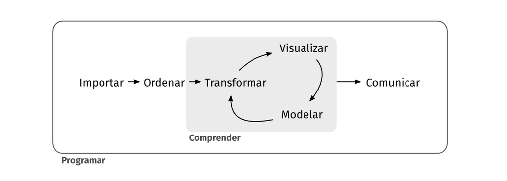

Fuente: Wickham and Grolemund, 2016

## Flujo de trabajo: *Proyectos*

- Siempre es recomendable trabajar dentro de un **proyecto**
- Nos aseguraremos que todos los archivos y carpetas necesarios estén siempre en un lugar único
- Trabajaremos con rutas relativas.
- Hacer la prueba y armar un proyecto para el seminario

[figure not shown]

Ejemplo de carpeta de proyecto

## Flujo de trabajo: *Objetos (1)*

Todo lo que creemos en `R` es un objeto. Y en esto `R` es totalmente distinto a lo que conocíamos.

```r
objeto <- "Yo soy un objeto"
```

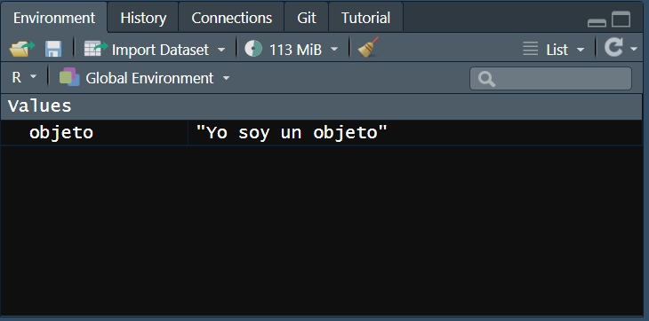

## Flujo de trabajo: *Objetos (2)*

Podemos crear objetos a partir de:

**Números**

```r
numeros <- 5625
```

**Palabras**

```r
Palabras <- "¡Hola amigos!"
```

**Vectores**: secuencias de números, palabras, etc.

```r
vector <- c(4,5,6,7,8)
```

Listas, *data frames*, gráficos, funciones, mapas y muchas cosas más.

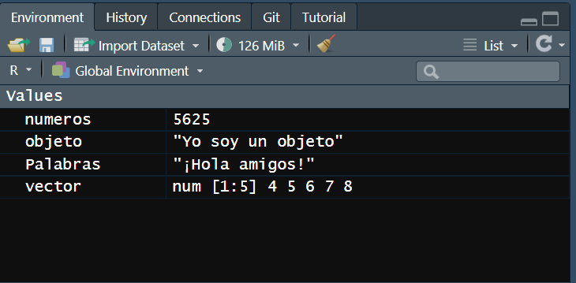

## Flujo de trabajo: *Elementos del script (caracteres especiales)*

- **De asignación** (`<-` o `=`): le asignan un valor a un objeto.
- **De anotación** (`#`): permite escribir anotación en el script que no son leídas como código
- **Pipa** (`%>%`): permite concatenar una secuencia de acciones sobre un objeto
  - Pertenece al paquete `magrittr` que está en `tidyverse`

## Flujo de trabajo: *Elementos del script (operadores)*

Operadores aritméticos

- `+` Suma
- `-` Resta
- `*` Multiplicación
- `/` División

Operadores relacionales

- `>` Mayor
- `>=` Mayor o igual
- `<` Menor
- `<=` Menor o igual
- `==` Igual
- `!=` Distinto

Operadores lógicos

- `&` y
- `|` ó

## Flujo de trabajo: *Objetos (3)*

Existe una *clase* especial de vector denominado factor

- Suelen ser utilizados como variables categóricas (nominales u ordinales)
- Tienen un conjunto fijo y conocido de valores que puede asumir
- Se suelen construir a partir de vectores de cadena

```r
clases_sociales <- c("alta", "media", "baja", "baja", "media", "media", "baja")
clases_factor <- factor(clases_sociales, levels = c("baja", "media", "alta"))
```

```r
table(clases_factor)
```

```
clases_factor
 baja media  alta
    3     3     1
```

## Principales funciones de `dplyr`

- Filter: filtrado de filas o casos
- Select: selección de columnas o variables
- Arrange: ordena los casos de una variable(s)
- Count: cuenta casos
- Mutate: crea nuevas columnas o variables
- Case_when: crea nuevas columnas o variables con condiciones
- Group_by / summarize: agregan casos por variable